# Risk Factor Analysis

## Outcome Variable

**Outcome Variable:** whz

## Predictor Variables

**Intervention Variable:** predfeed3

**Adjustment Set:**

unadjusted

## Stratifying Variables

The analysis was stratified on these variable(s):

- agecat
- studyid
- country

## Data Summary

| agecat | studyid | country | predfeed3 | n_cell | n |
| --- | --- | --- | --- | --- | --- |
| Birth | ki0047075b-MAL-ED | BANGLADESH | 1 | 193 | 227 |
| Birth | ki0047075b-MAL-ED | BANGLADESH | 0 | 34 | 227 |
| Birth | ki0047075b-MAL-ED | BRAZIL | 1 | 97 | 177 |
| Birth | ki0047075b-MAL-ED | BRAZIL | 0 | 80 | 177 |
| Birth | ki0047075b-MAL-ED | INDIA | 1 | 150 | 193 |
| Birth | ki0047075b-MAL-ED | INDIA | 0 | 43 | 193 |
| Birth | ki0047075b-MAL-ED | NEPAL | 1 | 97 | 166 |
| Birth | ki0047075b-MAL-ED | NEPAL | 0 | 69 | 166 |
| Birth | ki0047075b-MAL-ED | PERU | 1 | 177 | 265 |
| Birth | ki0047075b-MAL-ED | PERU | 0 | 88 | 265 |
| Birth | ki0047075b-MAL-ED | SOUTH AFRICA | 1 | 87 | 231 |
| Birth | ki0047075b-MAL-ED | SOUTH AFRICA | 0 | 144 | 231 |
| Birth | ki0047075b-MAL-ED | TANZANIA, UNITED REPUBLIC OF | 1 | 49 | 114 |
| Birth | ki0047075b-MAL-ED | TANZANIA, UNITED REPUBLIC OF | 0 | 65 | 114 |
| Birth | ki1000109-EE | PAKISTAN | 1 | 1 | 1 |
| Birth | ki1000109-EE | PAKISTAN | 0 | 0 | 1 |
| Birth | kiGH5241-JiVitA-3 | BANGLADESH | 1 | 13739 | 15136 |
| Birth | kiGH5241-JiVitA-3 | BANGLADESH | 0 | 1397 | 15136 |
| Birth | kiGH5241-JiVitA-4 | BANGLADESH | 1 | 28 | 31 |
| Birth | kiGH5241-JiVitA-4 | BANGLADESH | 0 | 3 | 31 |
| 6 months | ki0047075b-MAL-ED | BANGLADESH | 1 | 203 | 237 |
| 6 months | ki0047075b-MAL-ED | BANGLADESH | 0 | 34 | 237 |
| 6 months | ki0047075b-MAL-ED | BRAZIL | 1 | 116 | 209 |
| 6 months | ki0047075b-MAL-ED | BRAZIL | 0 | 93 | 209 |
| 6 months | ki0047075b-MAL-ED | INDIA | 1 | 178 | 233 |
| 6 months | ki0047075b-MAL-ED | INDIA | 0 | 55 | 233 |
| 6 months | ki0047075b-MAL-ED | NEPAL | 1 | 132 | 233 |
| 6 months | ki0047075b-MAL-ED | NEPAL | 0 | 101 | 233 |
| 6 months | ki0047075b-MAL-ED | PERU | 1 | 183 | 270 |
| 6 months | ki0047075b-MAL-ED | PERU | 0 | 87 | 270 |
| 6 months | ki0047075b-MAL-ED | SOUTH AFRICA | 1 | 86 | 248 |
| 6 months | ki0047075b-MAL-ED | SOUTH AFRICA | 0 | 162 | 248 |
| 6 months | ki0047075b-MAL-ED | TANZANIA, UNITED REPUBLIC OF | 1 | 91 | 240 |
| 6 months | ki0047075b-MAL-ED | TANZANIA, UNITED REPUBLIC OF | 0 | 149 | 240 |
| 6 months | ki1000109-EE | PAKISTAN | 1 | 349 | 375 |
| 6 months | ki1000109-EE | PAKISTAN | 0 | 26 | 375 |
| 6 months | ki1113344-GMS-Nepal | NEPAL | 1 | 379 | 458 |
| 6 months | ki1113344-GMS-Nepal | NEPAL | 0 | 79 | 458 |
| 6 months | kiGH5241-JiVitA-3 | BANGLADESH | 1 | 14763 | 16253 |
| 6 months | kiGH5241-JiVitA-3 | BANGLADESH | 0 | 1490 | 16253 |
| 6 months | kiGH5241-JiVitA-4 | BANGLADESH | 1 | 77 | 89 |
| 6 months | kiGH5241-JiVitA-4 | BANGLADESH | 0 | 12 | 89 |
| 24 months | ki0047075b-MAL-ED | BANGLADESH | 1 | 178 | 208 |
| 24 months | ki0047075b-MAL-ED | BANGLADESH | 0 | 30 | 208 |
| 24 months | ki0047075b-MAL-ED | BRAZIL | 1 | 98 | 169 |
| 24 months | ki0047075b-MAL-ED | BRAZIL | 0 | 71 | 169 |
| 24 months | ki0047075b-MAL-ED | INDIA | 1 | 170 | 225 |
| 24 months | ki0047075b-MAL-ED | INDIA | 0 | 55 | 225 |
| 24 months | ki0047075b-MAL-ED | NEPAL | 1 | 128 | 225 |
| 24 months | ki0047075b-MAL-ED | NEPAL | 0 | 97 | 225 |
| 24 months | ki0047075b-MAL-ED | PERU | 1 | 137 | 199 |
| 24 months | ki0047075b-MAL-ED | PERU | 0 | 62 | 199 |
| 24 months | ki0047075b-MAL-ED | SOUTH AFRICA | 1 | 81 | 232 |
| 24 months | ki0047075b-MAL-ED | SOUTH AFRICA | 0 | 151 | 232 |
| 24 months | ki0047075b-MAL-ED | TANZANIA, UNITED REPUBLIC OF | 1 | 79 | 210 |
| 24 months | ki0047075b-MAL-ED | TANZANIA, UNITED REPUBLIC OF | 0 | 131 | 210 |
| 24 months | ki1113344-GMS-Nepal | NEPAL | 1 | 336 | 404 |
| 24 months | ki1113344-GMS-Nepal | NEPAL | 0 | 68 | 404 |
| 24 months | kiGH5241-JiVitA-3 | BANGLADESH | 1 | 7495 | 8313 |
| 24 months | kiGH5241-JiVitA-3 | BANGLADESH | 0 | 818 | 8313 |
| 24 months | kiGH5241-JiVitA-4 | BANGLADESH | 1 | 136 | 151 |
| 24 months | kiGH5241-JiVitA-4 | BANGLADESH | 0 | 15 | 151 |

The following strata were considered:

- agecat: 24 months, studyid: ki0047075b-MAL-ED, country: BANGLADESH
- agecat: 24 months, studyid: ki0047075b-MAL-ED, country: BRAZIL
- agecat: 24 months, studyid: ki0047075b-MAL-ED, country: INDIA
- agecat: 24 months, studyid: ki0047075b-MAL-ED, country: NEPAL
- agecat: 24 months, studyid: ki0047075b-MAL-ED, country: PERU
- agecat: 24 months, studyid: ki0047075b-MAL-ED, country: SOUTH AFRICA
- agecat: 24 months, studyid: ki0047075b-MAL-ED, country: TANZANIA, UNITED REPUBLIC OF
- agecat: 24 months, studyid: ki1113344-GMS-Nepal, country: NEPAL
- agecat: 24 months, studyid: kiGH5241-JiVitA-3, country: BANGLADESH
- agecat: 24 months, studyid: kiGH5241-JiVitA-4, country: BANGLADESH
- agecat: 6 months, studyid: ki0047075b-MAL-ED, country: BANGLADESH
- agecat: 6 months, studyid: ki0047075b-MAL-ED, country: BRAZIL
- agecat: 6 months, studyid: ki0047075b-MAL-ED, country: INDIA
- agecat: 6 months, studyid: ki0047075b-MAL-ED, country: NEPAL
- agecat: 6 months, studyid: ki0047075b-MAL-ED, country: PERU
- agecat: 6 months, studyid: ki0047075b-MAL-ED, country: SOUTH AFRICA
- agecat: 6 months, studyid: ki0047075b-MAL-ED, country: TANZANIA, UNITED REPUBLIC OF
- agecat: 6 months, studyid: ki1000109-EE, country: PAKISTAN
- agecat: 6 months, studyid: ki1113344-GMS-Nepal, country: NEPAL
- agecat: 6 months, studyid: kiGH5241-JiVitA-3, country: BANGLADESH
- agecat: 6 months, studyid: kiGH5241-JiVitA-4, country: BANGLADESH
- agecat: Birth, studyid: ki0047075b-MAL-ED, country: BANGLADESH
- agecat: Birth, studyid: ki0047075b-MAL-ED, country: BRAZIL
- agecat: Birth, studyid: ki0047075b-MAL-ED, country: INDIA
- agecat: Birth, studyid: ki0047075b-MAL-ED, country: NEPAL
- agecat: Birth, studyid: ki0047075b-MAL-ED, country: PERU
- agecat: Birth, studyid: ki0047075b-MAL-ED, country: SOUTH AFRICA
- agecat: Birth, studyid: ki0047075b-MAL-ED, country: TANZANIA, UNITED REPUBLIC OF
- agecat: Birth, studyid: ki1000109-EE, country: PAKISTAN
- agecat: Birth, studyid: kiGH5241-JiVitA-3, country: BANGLADESH
- agecat: Birth, studyid: kiGH5241-JiVitA-4, country: BANGLADESH

### Dropped Strata

Some strata were dropped due to rare outcomes:

- agecat: Birth, studyid: ki1000109-EE, country: PAKISTAN
- agecat: Birth, studyid: kiGH5241-JiVitA-4, country: BANGLADESH

## Methods Detail

We’re interested in the causal parameters $E[Y_a]$ for all values of $a \in \mathcal{A}$. These parameters represent the mean outcome if, possibly contrary to fact, we intervened to set all units to have $A=a$. Under the randomization and positivity assumptions, these are identified by the statistical parameters $\psi_a=E_W[E_{Y|A,W}(Y|A=a,W)]$. In addition, we’re interested in the mean of $Y$, $E[Y]$ under no intervention (the observed mean). We will estimate these parameters by using SuperLearner to fit the relevant likelihood factors – $E_{Y|A,W}(Y|A=a,W)$ and $p(A=a|W)$, and then updating our likelihood fit using a joint TMLE.

For unadjusted analyses ($W=\{\}$), initial likelihoods were estimated using Lrnr_glm to estimate the simple $E(Y|A)$ and Lrnr_mean to estimate $p(A)$. For adjusted analyses, a small library containing Lrnr_glmnet, Lrnr_xgboost, and Lrnr_mean was used.

# Results Detail

## Results Plots

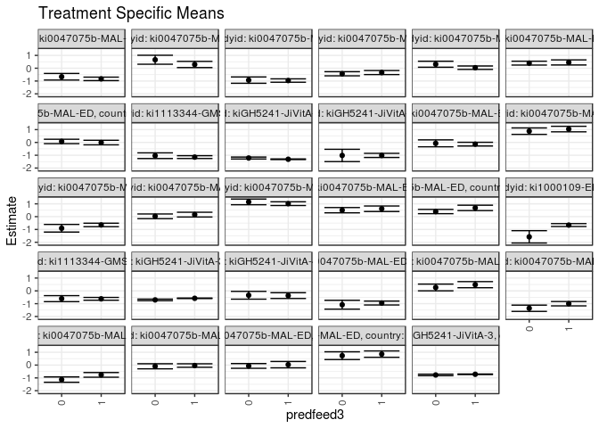

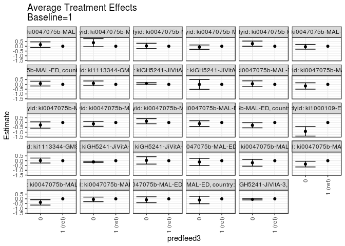

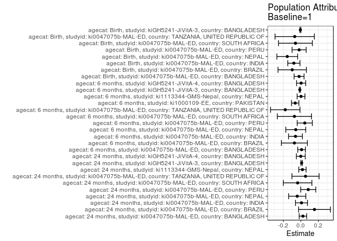

## Results Table

### Parameter: TSM

| agecat | studyid | country | intervention_level | baseline_level | estimate | ci_lower | ci_upper |
| --- | --- | --- | --- | --- | --- | --- | --- |
| Birth | ki0047075b-MAL-ED | BANGLADESH | 1 | NA | -0.9504145 | -1.1022451 | -0.7985840 |
| Birth | ki0047075b-MAL-ED | BANGLADESH | 0 | NA | -1.0823529 | -1.4272123 | -0.7374936 |
| Birth | ki0047075b-MAL-ED | BRAZIL | 1 | NA | 0.4816495 | 0.2421413 | 0.7211576 |
| Birth | ki0047075b-MAL-ED | BRAZIL | 0 | NA | 0.2650000 | 0.0020958 | 0.5279042 |
| Birth | ki0047075b-MAL-ED | INDIA | 1 | NA | -1.0032667 | -1.1719757 | -0.8345577 |
| Birth | ki0047075b-MAL-ED | INDIA | 0 | NA | -1.3586047 | -1.6034440 | -1.1137653 |
| Birth | ki0047075b-MAL-ED | NEPAL | 1 | NA | -0.7641237 | -0.9456153 | -0.5826321 |
| Birth | ki0047075b-MAL-ED | NEPAL | 0 | NA | -1.1353623 | -1.3438529 | -0.9268718 |
| Birth | ki0047075b-MAL-ED | PERU | 1 | NA | -0.0364407 | -0.1735906 | 0.1007093 |
| Birth | ki0047075b-MAL-ED | PERU | 0 | NA | -0.0948864 | -0.2933938 | 0.1036210 |
| Birth | ki0047075b-MAL-ED | SOUTH AFRICA | 1 | NA | 0.0320690 | -0.2154504 | 0.2795883 |
| Birth | ki0047075b-MAL-ED | SOUTH AFRICA | 0 | NA | -0.0659722 | -0.2505173 | 0.1185728 |
| Birth | ki0047075b-MAL-ED | TANZANIA, UNITED REPUBLIC OF | 1 | NA | 0.8561224 | 0.6074155 | 1.1048294 |
| Birth | ki0047075b-MAL-ED | TANZANIA, UNITED REPUBLIC OF | 0 | NA | 0.7341538 | 0.4313412 | 1.0369665 |
| Birth | kiGH5241-JiVitA-3 | BANGLADESH | 1 | NA | -0.7171796 | -0.7378792 | -0.6964800 |
| Birth | kiGH5241-JiVitA-3 | BANGLADESH | 0 | NA | -0.7720687 | -0.8316078 | -0.7125297 |
| 6 months | ki0047075b-MAL-ED | BANGLADESH | 1 | NA | -0.1334195 | -0.2780713 | 0.0112322 |
| 6 months | ki0047075b-MAL-ED | BANGLADESH | 0 | NA | -0.0718137 | -0.3424529 | 0.1988255 |
| 6 months | ki0047075b-MAL-ED | BRAZIL | 1 | NA | 1.0446983 | 0.8285826 | 1.2608139 |
| 6 months | ki0047075b-MAL-ED | BRAZIL | 0 | NA | 0.8806989 | 0.6294598 | 1.1319381 |
| 6 months | ki0047075b-MAL-ED | INDIA | 1 | NA | -0.6498970 | -0.7859779 | -0.5138161 |
| 6 months | ki0047075b-MAL-ED | INDIA | 0 | NA | -0.9067273 | -1.2051210 | -0.6083336 |
| 6 months | ki0047075b-MAL-ED | NEPAL | 1 | NA | 0.1586364 | -0.0268954 | 0.3441682 |
| 6 months | ki0047075b-MAL-ED | NEPAL | 0 | NA | 0.0258086 | -0.1568237 | 0.2084409 |
| 6 months | ki0047075b-MAL-ED | PERU | 1 | NA | 1.0124044 | 0.8662012 | 1.1586076 |
| 6 months | ki0047075b-MAL-ED | PERU | 0 | NA | 1.1512069 | 0.9288741 | 1.3735397 |
| 6 months | ki0047075b-MAL-ED | SOUTH AFRICA | 1 | NA | 0.6162791 | 0.4008579 | 0.8317002 |
| 6 months | ki0047075b-MAL-ED | SOUTH AFRICA | 0 | NA | 0.5049486 | 0.2990191 | 0.7108780 |
| 6 months | ki0047075b-MAL-ED | TANZANIA, UNITED REPUBLIC OF | 1 | NA | 0.6834615 | 0.4732199 | 0.8937031 |
| 6 months | ki0047075b-MAL-ED | TANZANIA, UNITED REPUBLIC OF | 0 | NA | 0.3981655 | 0.2315886 | 0.5647425 |
| 6 months | ki1000109-EE | PAKISTAN | 1 | NA | -0.6581519 | -0.7721469 | -0.5441568 |
| 6 months | ki1000109-EE | PAKISTAN | 0 | NA | -1.5771154 | -2.0585012 | -1.0957295 |
| 6 months | ki1113344-GMS-Nepal | NEPAL | 1 | NA | -0.6219041 | -0.7296979 | -0.5141104 |
| 6 months | ki1113344-GMS-Nepal | NEPAL | 0 | NA | -0.6074262 | -0.8417625 | -0.3730898 |
| 6 months | kiGH5241-JiVitA-3 | BANGLADESH | 1 | NA | -0.5815756 | -0.6024503 | -0.5607008 |
| 6 months | kiGH5241-JiVitA-3 | BANGLADESH | 0 | NA | -0.7060805 | -0.7674956 | -0.6446654 |
| 6 months | kiGH5241-JiVitA-4 | BANGLADESH | 1 | NA | -0.3693506 | -0.5952577 | -0.1434436 |
| 6 months | kiGH5241-JiVitA-4 | BANGLADESH | 0 | NA | -0.3425000 | -0.6465948 | -0.0384052 |
| 24 months | ki0047075b-MAL-ED | BANGLADESH | 1 | NA | -0.8319382 | -0.9676630 | -0.6962134 |
| 24 months | ki0047075b-MAL-ED | BANGLADESH | 0 | NA | -0.6665000 | -0.9232479 | -0.4097521 |
| 24 months | ki0047075b-MAL-ED | BRAZIL | 1 | NA | 0.2911224 | 0.0489480 | 0.5332969 |
| 24 months | ki0047075b-MAL-ED | BRAZIL | 0 | NA | 0.6612676 | 0.3118785 | 1.0106567 |
| 24 months | ki0047075b-MAL-ED | INDIA | 1 | NA | -0.9632353 | -1.0947597 | -0.8317109 |
| 24 months | ki0047075b-MAL-ED | INDIA | 0 | NA | -0.9300000 | -1.1769912 | -0.6830088 |
| 24 months | ki0047075b-MAL-ED | NEPAL | 1 | NA | -0.3387109 | -0.4977150 | -0.1797069 |
| 24 months | ki0047075b-MAL-ED | NEPAL | 0 | NA | -0.4334536 | -0.5947369 | -0.2721703 |
| 24 months | ki0047075b-MAL-ED | PERU | 1 | NA | 0.0398905 | -0.0940643 | 0.1738453 |
| 24 months | ki0047075b-MAL-ED | PERU | 0 | NA | 0.3107258 | 0.0767613 | 0.5446903 |
| 24 months | ki0047075b-MAL-ED | SOUTH AFRICA | 1 | NA | 0.4521605 | 0.2530658 | 0.6512552 |
| 24 months | ki0047075b-MAL-ED | SOUTH AFRICA | 0 | NA | 0.3962252 | 0.2453223 | 0.5471281 |
| 24 months | ki0047075b-MAL-ED | TANZANIA, UNITED REPUBLIC OF | 1 | NA | -0.0101899 | -0.1893661 | 0.1689864 |
| 24 months | ki0047075b-MAL-ED | TANZANIA, UNITED REPUBLIC OF | 0 | NA | 0.0757634 | -0.0956006 | 0.2471273 |
| 24 months | ki1113344-GMS-Nepal | NEPAL | 1 | NA | -1.1452034 | -1.2553910 | -1.0350158 |
| 24 months | ki1113344-GMS-Nepal | NEPAL | 0 | NA | -1.0355392 | -1.2573278 | -0.8137506 |
| 24 months | kiGH5241-JiVitA-3 | BANGLADESH | 1 | NA | -1.3125083 | -1.3377187 | -1.2872980 |
| 24 months | kiGH5241-JiVitA-3 | BANGLADESH | 0 | NA | -1.2169071 | -1.2921634 | -1.1416508 |
| 24 months | kiGH5241-JiVitA-4 | BANGLADESH | 1 | NA | -1.0133824 | -1.1743134 | -0.8524513 |
| 24 months | kiGH5241-JiVitA-4 | BANGLADESH | 0 | NA | -1.0166667 | -1.4966704 | -0.5366630 |

### Parameter: E(Y)

| agecat | studyid | country | intervention_level | baseline_level | estimate | ci_lower | ci_upper |
| --- | --- | --- | --- | --- | --- | --- | --- |
| Birth | ki0047075b-MAL-ED | BANGLADESH | NA | NA | -0.9701762 | -1.1093516 | -0.8310008 |
| Birth | ki0047075b-MAL-ED | BRAZIL | NA | NA | 0.3837288 | 0.2059602 | 0.5614974 |
| Birth | ki0047075b-MAL-ED | INDIA | NA | NA | -1.0824352 | -1.2259825 | -0.9388879 |
| Birth | ki0047075b-MAL-ED | NEPAL | NA | NA | -0.9184337 | -1.0582074 | -0.7786600 |
| Birth | ki0047075b-MAL-ED | PERU | NA | NA | -0.0558491 | -0.1687562 | 0.0570581 |
| Birth | ki0047075b-MAL-ED | SOUTH AFRICA | NA | NA | -0.0290476 | -0.1772448 | 0.1191495 |
| Birth | ki0047075b-MAL-ED | TANZANIA, UNITED REPUBLIC OF | NA | NA | 0.7865789 | 0.5832028 | 0.9899551 |
| Birth | kiGH5241-JiVitA-3 | BANGLADESH | NA | NA | -0.7222456 | -0.7423351 | -0.7021562 |
| 6 months | ki0047075b-MAL-ED | BANGLADESH | NA | NA | -0.1245816 | -0.2544517 | 0.0052886 |
| 6 months | ki0047075b-MAL-ED | BRAZIL | NA | NA | 0.9717225 | 0.8073791 | 1.1360658 |
| 6 months | ki0047075b-MAL-ED | INDIA | NA | NA | -0.7105222 | -0.8368775 | -0.5841669 |
| 6 months | ki0047075b-MAL-ED | NEPAL | NA | NA | 0.1010587 | -0.0308005 | 0.2329178 |
| 6 months | ki0047075b-MAL-ED | PERU | NA | NA | 1.0571296 | 0.9346064 | 1.1796528 |
| 6 months | ki0047075b-MAL-ED | SOUTH AFRICA | NA | NA | 0.5435551 | 0.3895443 | 0.6975659 |
| 6 months | ki0047075b-MAL-ED | TANZANIA, UNITED REPUBLIC OF | NA | NA | 0.5063403 | 0.3745918 | 0.6380888 |
| 6 months | ki1000109-EE | PAKISTAN | NA | NA | -0.7218667 | -0.8355727 | -0.6081607 |
| 6 months | ki1113344-GMS-Nepal | NEPAL | NA | NA | -0.6194068 | -0.7173394 | -0.5214742 |
| 6 months | kiGH5241-JiVitA-3 | BANGLADESH | NA | NA | -0.5929896 | -0.6128338 | -0.5731455 |
| 6 months | kiGH5241-JiVitA-4 | BANGLADESH | NA | NA | -0.3657303 | -0.5647992 | -0.1666615 |
| 24 months | ki0047075b-MAL-ED | BANGLADESH | NA | NA | -0.8080769 | -0.9302432 | -0.6859106 |
| 24 months | ki0047075b-MAL-ED | BRAZIL | NA | NA | 0.4466272 | 0.2416144 | 0.6516401 |
| 24 months | ki0047075b-MAL-ED | INDIA | NA | NA | -0.9551111 | -1.0714034 | -0.8388188 |
| 24 months | ki0047075b-MAL-ED | NEPAL | NA | NA | -0.3795556 | -0.4938120 | -0.2652991 |
| 24 months | ki0047075b-MAL-ED | PERU | NA | NA | 0.1242714 | 0.0054301 | 0.2431126 |
| 24 months | ki0047075b-MAL-ED | SOUTH AFRICA | NA | NA | 0.4157543 | 0.2953789 | 0.5361297 |
| 24 months | ki0047075b-MAL-ED | TANZANIA, UNITED REPUBLIC OF | NA | NA | 0.0434286 | -0.0830724 | 0.1699295 |
| 24 months | ki1113344-GMS-Nepal | NEPAL | NA | NA | -1.1267450 | -1.2257791 | -1.0277110 |
| 24 months | kiGH5241-JiVitA-3 | BANGLADESH | NA | NA | -1.3031012 | -1.3269655 | -1.2792368 |
| 24 months | kiGH5241-JiVitA-4 | BANGLADESH | NA | NA | -1.0137086 | -1.1659964 | -0.8614208 |

### Parameter: ATE

| agecat | studyid | country | intervention_level | baseline_level | estimate | ci_lower | ci_upper |
| --- | --- | --- | --- | --- | --- | --- | --- |
| Birth | ki0047075b-MAL-ED | BANGLADESH | 1 | 1 | 0.0000000 | 0.0000000 | 0.0000000 |
| Birth | ki0047075b-MAL-ED | BANGLADESH | 0 | 1 | -0.1319384 | -0.5087414 | 0.2448645 |
| Birth | ki0047075b-MAL-ED | BRAZIL | 1 | 1 | 0.0000000 | 0.0000000 | 0.0000000 |
| Birth | ki0047075b-MAL-ED | BRAZIL | 0 | 1 | -0.2166495 | -0.5722937 | 0.1389947 |
| Birth | ki0047075b-MAL-ED | INDIA | 1 | 1 | 0.0000000 | 0.0000000 | 0.0000000 |
| Birth | ki0047075b-MAL-ED | INDIA | 0 | 1 | -0.3553380 | -0.6526746 | -0.0580014 |
| Birth | ki0047075b-MAL-ED | NEPAL | 1 | 1 | 0.0000000 | 0.0000000 | 0.0000000 |
| Birth | ki0047075b-MAL-ED | NEPAL | 0 | 1 | -0.3712386 | -0.6476577 | -0.0948195 |
| Birth | ki0047075b-MAL-ED | PERU | 1 | 1 | 0.0000000 | 0.0000000 | 0.0000000 |
| Birth | ki0047075b-MAL-ED | PERU | 0 | 1 | -0.0584457 | -0.2997242 | 0.1828328 |
| Birth | ki0047075b-MAL-ED | SOUTH AFRICA | 1 | 1 | 0.0000000 | 0.0000000 | 0.0000000 |
| Birth | ki0047075b-MAL-ED | SOUTH AFRICA | 0 | 1 | -0.0980412 | -0.4067849 | 0.2107025 |
| Birth | ki0047075b-MAL-ED | TANZANIA, UNITED REPUBLIC OF | 1 | 1 | 0.0000000 | 0.0000000 | 0.0000000 |
| Birth | ki0047075b-MAL-ED | TANZANIA, UNITED REPUBLIC OF | 0 | 1 | -0.1219686 | -0.5138240 | 0.2698868 |
| Birth | kiGH5241-JiVitA-3 | BANGLADESH | 1 | 1 | 0.0000000 | 0.0000000 | 0.0000000 |
| Birth | kiGH5241-JiVitA-3 | BANGLADESH | 0 | 1 | -0.0548892 | -0.1159371 | 0.0061588 |
| 6 months | ki0047075b-MAL-ED | BANGLADESH | 1 | 1 | 0.0000000 | 0.0000000 | 0.0000000 |
| 6 months | ki0047075b-MAL-ED | BANGLADESH | 0 | 1 | 0.0616058 | -0.2452650 | 0.3684766 |
| 6 months | ki0047075b-MAL-ED | BRAZIL | 1 | 1 | 0.0000000 | 0.0000000 | 0.0000000 |
| 6 months | ki0047075b-MAL-ED | BRAZIL | 0 | 1 | -0.1639994 | -0.4954011 | 0.1674024 |
| 6 months | ki0047075b-MAL-ED | INDIA | 1 | 1 | 0.0000000 | 0.0000000 | 0.0000000 |
| 6 months | ki0047075b-MAL-ED | INDIA | 0 | 1 | -0.2568303 | -0.5847889 | 0.0711283 |
| 6 months | ki0047075b-MAL-ED | NEPAL | 1 | 1 | 0.0000000 | 0.0000000 | 0.0000000 |
| 6 months | ki0047075b-MAL-ED | NEPAL | 0 | 1 | -0.1328278 | -0.3931672 | 0.1275116 |
| 6 months | ki0047075b-MAL-ED | PERU | 1 | 1 | 0.0000000 | 0.0000000 | 0.0000000 |
| 6 months | ki0047075b-MAL-ED | PERU | 0 | 1 | 0.1388025 | -0.1272938 | 0.4048989 |
| 6 months | ki0047075b-MAL-ED | SOUTH AFRICA | 1 | 1 | 0.0000000 | 0.0000000 | 0.0000000 |
| 6 months | ki0047075b-MAL-ED | SOUTH AFRICA | 0 | 1 | -0.1113305 | -0.4093459 | 0.1866849 |
| 6 months | ki0047075b-MAL-ED | TANZANIA, UNITED REPUBLIC OF | 1 | 1 | 0.0000000 | 0.0000000 | 0.0000000 |
| 6 months | ki0047075b-MAL-ED | TANZANIA, UNITED REPUBLIC OF | 0 | 1 | -0.2852960 | -0.5535298 | -0.0170621 |
| 6 months | ki1000109-EE | PAKISTAN | 1 | 1 | 0.0000000 | 0.0000000 | 0.0000000 |
| 6 months | ki1000109-EE | PAKISTAN | 0 | 1 | -0.9189635 | -1.4136626 | -0.4242644 |
| 6 months | ki1113344-GMS-Nepal | NEPAL | 1 | 1 | 0.0000000 | 0.0000000 | 0.0000000 |
| 6 months | ki1113344-GMS-Nepal | NEPAL | 0 | 1 | 0.0144780 | -0.2434620 | 0.2724179 |
| 6 months | kiGH5241-JiVitA-3 | BANGLADESH | 1 | 1 | 0.0000000 | 0.0000000 | 0.0000000 |
| 6 months | kiGH5241-JiVitA-3 | BANGLADESH | 0 | 1 | -0.1245050 | -0.1890312 | -0.0599787 |
| 6 months | kiGH5241-JiVitA-4 | BANGLADESH | 1 | 1 | 0.0000000 | 0.0000000 | 0.0000000 |
| 6 months | kiGH5241-JiVitA-4 | BANGLADESH | 0 | 1 | 0.0268506 | -0.3552485 | 0.4089498 |
| 24 months | ki0047075b-MAL-ED | BANGLADESH | 1 | 1 | 0.0000000 | 0.0000000 | 0.0000000 |
| 24 months | ki0047075b-MAL-ED | BANGLADESH | 0 | 1 | 0.1654382 | -0.1249765 | 0.4558529 |
| 24 months | ki0047075b-MAL-ED | BRAZIL | 1 | 1 | 0.0000000 | 0.0000000 | 0.0000000 |
| 24 months | ki0047075b-MAL-ED | BRAZIL | 0 | 1 | 0.3701452 | -0.0549680 | 0.7952584 |
| 24 months | ki0047075b-MAL-ED | INDIA | 1 | 1 | 0.0000000 | 0.0000000 | 0.0000000 |
| 24 months | ki0047075b-MAL-ED | INDIA | 0 | 1 | 0.0332353 | -0.2465920 | 0.3130626 |
| 24 months | ki0047075b-MAL-ED | NEPAL | 1 | 1 | 0.0000000 | 0.0000000 | 0.0000000 |
| 24 months | ki0047075b-MAL-ED | NEPAL | 0 | 1 | -0.0947427 | -0.3212257 | 0.1317404 |
| 24 months | ki0047075b-MAL-ED | PERU | 1 | 1 | 0.0000000 | 0.0000000 | 0.0000000 |
| 24 months | ki0047075b-MAL-ED | PERU | 0 | 1 | 0.2708353 | 0.0012370 | 0.5404336 |
| 24 months | ki0047075b-MAL-ED | SOUTH AFRICA | 1 | 1 | 0.0000000 | 0.0000000 | 0.0000000 |
| 24 months | ki0047075b-MAL-ED | SOUTH AFRICA | 0 | 1 | -0.0559353 | -0.3057560 | 0.1938854 |
| 24 months | ki0047075b-MAL-ED | TANZANIA, UNITED REPUBLIC OF | 1 | 1 | 0.0000000 | 0.0000000 | 0.0000000 |
| 24 months | ki0047075b-MAL-ED | TANZANIA, UNITED REPUBLIC OF | 0 | 1 | 0.0859532 | -0.1619776 | 0.3338841 |
| 24 months | ki1113344-GMS-Nepal | NEPAL | 1 | 1 | 0.0000000 | 0.0000000 | 0.0000000 |
| 24 months | ki1113344-GMS-Nepal | NEPAL | 0 | 1 | 0.1096642 | -0.1379878 | 0.3573161 |
| 24 months | kiGH5241-JiVitA-3 | BANGLADESH | 1 | 1 | 0.0000000 | 0.0000000 | 0.0000000 |
| 24 months | kiGH5241-JiVitA-3 | BANGLADESH | 0 | 1 | 0.0956012 | 0.0160684 | 0.1751341 |
| 24 months | kiGH5241-JiVitA-4 | BANGLADESH | 1 | 1 | 0.0000000 | 0.0000000 | 0.0000000 |
| 24 months | kiGH5241-JiVitA-4 | BANGLADESH | 0 | 1 | -0.0032843 | -0.5105203 | 0.5039517 |

### Parameter: PAR

| agecat | studyid | country | intervention_level | baseline_level | estimate | ci_lower | ci_upper |
| --- | --- | --- | --- | --- | --- | --- | --- |
| Birth | ki0047075b-MAL-ED | BANGLADESH | 1 | NA | -0.0197617 | -0.0765320 | 0.0370086 |
| Birth | ki0047075b-MAL-ED | BRAZIL | 1 | NA | -0.0979207 | -0.2594512 | 0.0636099 |
| Birth | ki0047075b-MAL-ED | INDIA | 1 | NA | -0.0791686 | -0.1486378 | -0.0096993 |
| Birth | ki0047075b-MAL-ED | NEPAL | 1 | NA | -0.1543100 | -0.2725499 | -0.0360701 |
| Birth | ki0047075b-MAL-ED | PERU | 1 | NA | -0.0194084 | -0.0995998 | 0.0607831 |
| Birth | ki0047075b-MAL-ED | SOUTH AFRICA | 1 | NA | -0.0611166 | -0.2536781 | 0.1314449 |
| Birth | ki0047075b-MAL-ED | TANZANIA, UNITED REPUBLIC OF | 1 | NA | -0.0695435 | -0.2932470 | 0.1541600 |
| Birth | kiGH5241-JiVitA-3 | BANGLADESH | 1 | NA | -0.0050661 | -0.0107265 | 0.0005944 |
| 6 months | ki0047075b-MAL-ED | BANGLADESH | 1 | NA | 0.0088380 | -0.0352718 | 0.0529478 |
| 6 months | ki0047075b-MAL-ED | BRAZIL | 1 | NA | -0.0729758 | -0.2208570 | 0.0749054 |
| 6 months | ki0047075b-MAL-ED | INDIA | 1 | NA | -0.0606252 | -0.1393021 | 0.0180517 |
| 6 months | ki0047075b-MAL-ED | NEPAL | 1 | NA | -0.0575777 | -0.1707461 | 0.0555907 |
| 6 months | ki0047075b-MAL-ED | PERU | 1 | NA | 0.0447253 | -0.0413666 | 0.1308171 |
| 6 months | ki0047075b-MAL-ED | SOUTH AFRICA | 1 | NA | -0.0727240 | -0.2675074 | 0.1220595 |
| 6 months | ki0047075b-MAL-ED | TANZANIA, UNITED REPUBLIC OF | 1 | NA | -0.1771213 | -0.3445719 | -0.0096707 |
| 6 months | ki1000109-EE | PAKISTAN | 1 | NA | -0.0637148 | -0.1053817 | -0.0220479 |
| 6 months | ki1113344-GMS-Nepal | NEPAL | 1 | NA | 0.0024973 | -0.0419974 | 0.0469919 |
| 6 months | kiGH5241-JiVitA-3 | BANGLADESH | 1 | NA | -0.0114140 | -0.0173709 | -0.0054571 |
| 6 months | kiGH5241-JiVitA-4 | BANGLADESH | 1 | NA | 0.0036203 | -0.0481153 | 0.0553559 |
| 24 months | ki0047075b-MAL-ED | BANGLADESH | 1 | NA | 0.0238613 | -0.0187672 | 0.0664898 |
| 24 months | ki0047075b-MAL-ED | BRAZIL | 1 | NA | 0.1555048 | -0.0252171 | 0.3362267 |
| 24 months | ki0047075b-MAL-ED | INDIA | 1 | NA | 0.0081242 | -0.0603036 | 0.0765520 |
| 24 months | ki0047075b-MAL-ED | NEPAL | 1 | NA | -0.0408446 | -0.1386771 | 0.0569879 |
| 24 months | ki0047075b-MAL-ED | PERU | 1 | NA | 0.0843808 | -0.0014124 | 0.1701741 |
| 24 months | ki0047075b-MAL-ED | SOUTH AFRICA | 1 | NA | -0.0364062 | -0.1990413 | 0.1262290 |
| 24 months | ki0047075b-MAL-ED | TANZANIA, UNITED REPUBLIC OF | 1 | NA | 0.0536184 | -0.1011462 | 0.2083831 |
| 24 months | ki1113344-GMS-Nepal | NEPAL | 1 | NA | 0.0184583 | -0.0234177 | 0.0603344 |
| 24 months | kiGH5241-JiVitA-3 | BANGLADESH | 1 | NA | 0.0094072 | 0.0015500 | 0.0172643 |
| 24 months | kiGH5241-JiVitA-4 | BANGLADESH | 1 | NA | -0.0003263 | -0.0506905 | 0.0500380 |